# Math 189: Factor Analysis II

# Maximum Likelihood Estimation Method

- An alternative approach to estimate the factor model is called the *Maximum Likelihood Estimation* (MLE) method.
- Using the MLE Method, we must assume that the data are independently sampled from a multivariate normal distribution with mean vector $\underline{\mu}$ and variance-covariance matrix ${\mathbf \Sigma}$ of the form:
  $${\mathbf \Sigma} =
  {\mathbf L} \, {\mathbf L}^{\prime} + {\mathbf \Psi}.$$
- In other words, we observe an iid sample $\underline{x}_1, \ldots, \underline{x}_n$ with distribution $\mathcal{N} (\underline{\mu}, {\mathbf L} \, {\mathbf L}^{\prime} + {\mathbf \Psi})$.
- The multivariate normal assumption allows us to establish a likelihood function for the factor model. However, this assumption can be restrictive in practice, as the real dataset we observe may not obey this assumption.
- Under the iid normal assumption, the joint density of $\underline{x}_1, \ldots, \underline{x}_n$ is
  $$f ( \underline{x}_1, \ldots, \underline{x}_n) = \prod_{i=1}^n f( \underline{x}_i)
  = {(2 \pi)}^{-np/2} { \det {\mathbf \Sigma}}^{-n/2}
  \, \exp \{ - \frac{1}{2} \sum_{i=1}^n {( \underline{x}_i - \underline{\mu} )}^{\prime}
  {\mathbf \Sigma}^{-1} ( \underline{x}_i - \underline{\mu } ) \}.$$
- Then, the log-likelihood function of $\underline{\mu}$, ${\mathbf L}$, and ${\mathbf \Psi}$ is (up to a constant, which we can ignore)
  $$\ell_n ( \underline{\mu}, {\mathbf L}, {\mathbf \Psi})
  = - \frac{n}{2} \log \det [ {\mathbf L} \, {\mathbf L}^{\prime} + {\mathbf \Psi} ]
  - \frac{1}{2} \sum_{i=1}^n {( \underline{x}_i - \underline{\mu} )}^{\prime}
  { ( {\mathbf L} \, {\mathbf L}^{\prime} + {\mathbf \Psi} ) }^{-1}
  ( \underline{x}_i - \underline{\mu } ).$$
- The maximum likelihood estimator for the mean vector $\underline{\mu}$, the factor loadings ${\mathbf L}$, and the specific variances ${\mathbf \Psi}$ are obtained by finding $\hat{\underline{\mu}}$, $\hat{\mathbf L}$, and $\hat{\mathbf \Psi}$ that maximize the log-likelihood $\ell_n ( \underline{\mu}, {\mathbf L}, {\mathbf \Psi})$.
- In general, there is no closed-form solution to this maximization problem. In practice, it is usually solved by iterative optimization algorithms.

# Factor Scores

- The common factors realized at each observation are called *factor scores*.
- Factor scores are similar to the principal components in the previous lecture. We can plot principal components against each other; a similar scatter plot of factor scores is also helpful.
- We also might use factor scores as explanatory variables in future analysis. It may even be of interest to use the factor score as the dependent variable in a future analysis.
- There are a number of different methods for estimating factor scores from the data. These include:
1. Ordinary Least Squares
2. Weighted Least Squares
3. Regression method

## Ordinary Least Squares Estimation of Factor

- Suppose we observe a sample $\underline{x}_1, \ldots, \underline{x}_n$. Denote by $\hat{\underline{\mu}}$ and $\hat{\mathbf L}$ the estimators of intercept and factor loading matrix obtained by either the PC method or MLE method.
- The factor scores can be estimated by solving linear regression problem
  $$\underline{x}_i = \hat{\underline{\mu}} + \hat{\mathbf L} \underline{f}_i + \underline{\epsilon}_i$$
  for $i = 1, \ldots, n$.
- The solution can be found by solving the least square problem:
  $$\hat{\underline{f}}_i = \mbox{arg min}_{\underline{f}}
  {( \underline{x}_i - \hat{\underline{\mu}} + \hat{\mathbf L} \underline{f}_i)}^{\prime}
  ( \underline{x}_i - \hat{\underline{\mu}} + \hat{\mathbf L} \underline{f}_i).$$
- The explicit solution admits the form
  $$\hat{\underline{f}}_i = { \left[ \hat{\mathbf L}^{\prime} \hat{\mathbf L} \right] }^{-1}
  \hat{\mathbf L}^{\prime} ( \underline{x}_i - \hat{\underline{\mu}} ).$$
  for $i = 1, \ldots, n$.

## Identifiability Issue

- Though we imposed some assumptions to avoid flexibility in factor model, there are still some ambiguities in the model.
- To explain: let ${\mathbf H}$ be any $m \times m$ orthogonal matrix. A matrix is *orthogonal* if its nverse is equal to its transpose:
  $${\mathbf H} \, {\mathbf H}^{\prime} = {\mathbf H}^{\prime} \, {\mathbf H} = I_m.$$
- Define ${\mathbf L}^* = {\mathbf L} \, {\mathbf H}$ and $\underline{f}^* = {\mathbf H}^{\prime} \underline{f}$. Then the factor model also holds with factor loading matrix ${\mathbf L}^*$ and factors $\underline{f}^*$, because
  $$\begin{align*}
  \underline{x} & = \underline{\mu} + {\mathbf L} \underline{f} + \underline{\epsilon} \\
  & = \underline{\mu} + {\mathbf L} \, {\mathbf H} {\mathbf H}^{\prime} \underline{f} + \underline{\epsilon} \\
  & = \underline{\mu} + {\mathbf L}^* \, \underline{f}^* + \underline{\epsilon}.
  \end{align*}$$
  In addition, it is easy to check that $\underline{f}^*$ satisfies all of our assumptions.
- This means that $\underline{f}$ and ${\mathbf L}$ are only *identifiable* up to an $m \times m$ orthogonal matrix ${\mathbf H}$.
- What is a non-identifiable model? Say two different values of the parameter vector yield the same distribution; then we have no way of inferring which parameter is true.

## Matrix Rotation

- In linear algebra, an orthogonal matrix with determinant 1 is also called a *rotation matrix*. It serves as a linear operator that rotates a set of orthogonal axes with a certain angle.
- Let’s consider a two-dimensional toy example. Consider a rotation matrix
  $${\mathbf H} = \left[ \begin{array}{cc} \cos \theta & -\sin \theta \\
  \sin \theta & \cos \theta \end{array} \right].$$
  Note the determinant equals one.
- When applied to a vector $\underline{x}$, ${\mathbf H}$ rotates it by an angle $\theta$. Why? Write $\underline{x}$ in polar coordinates:
  $$\underline{x} = \left[ \begin{array}{c} r \cos \phi \\ r \sin \phi \end{array} \right],$$
  where $r$ is the length of the vector and $\phi$ is the angle of the vector with the x-axis. Then
  $${\mathbf H} \underline{x} = \left[ \begin{array}{c} r \cos \theta \, \cos \phi
  - r \sin \theta \sin \phi \\
  r \sin \theta \cos \phi + r \cos \theta \sin \phi \end{array} \right]
  = \left[ \begin{array}{c} r \cos ( \phi + \theta) \\ r \sin ( \phi + \theta)
  \end{array} \right],$$
  which shows that the angle $\phi$ has been rotated to $\phi + \theta$ (a couonter-clockwise rotation of the vector).

## Factor Rotation

- Since $\underline{f}$ and ${\mathbf L}$ are only identifiable up to an $m \times m$ orthogonal matrix ${\mathbf H}$, we have the freedom to choose a set of orthogonal axes in the $m$-dimensional linear space spanned by factor loading matrix ${\mathbf L}$.
- A good choice of rotation matrix ${\mathbf H}$ can yield easily interpretable factors and a clear explanation of the dataset.
- On the other hand, a bad choice of rotation matrix ${\mathbf H}$ can lead to uninterpretable factors and blur the explanation of the dataset.
- In general, there is no universal “good choice” of ${\mathbf H}$. It usually relies on the researcher’ss domain knowledge and experience to find which ${\mathbf H}$ leads to more interpretable factors.

## Example: Subject Preference Data

- This dataset contains a hypothetical sample of 300 responses on 6 items from a survey of college students’ favorite subject matter.
- In this survey, students are asked to rate their preference of 6 different college subject matter areas, including biology (BIO), geology (GEO), chemistry (CHEM), algebra (ALG), calculus (CALC), and statistics (STAT).
- For each subject, the response ranges from 1 to 5, which represent a scale from Strongly Dislike to Strongly Like.

### A Peek at the Dataset

- Let’s first have a peek at the dataset and some descriptive statistics.

```r
df<- read.csv("dataset_EFA.csv")
head(df)
```

```
##   BIO GEO CHEM ALG CALC STAT
## 1   1   1    1   1    1    1
## 2   4   4    3   4    4    4
## 3   2   1    3   4    1    1
## 4   2   3    2   4    4    3
## 5   3   1    2   2    3    4
## 6   1   1    1   4    4    4
```

```r
out <- rbind(apply(df, 2, mean),apply(df, 2, var))
colnames(out) <- c("Biology","Geology","Chemistry","Algebra","Calculus","Statistics")
rownames(out) <- c("Mean","Varaiance")
out
```

```
##            Biology  Geology Chemistry  Algebra Calculus Statistics
## Mean      2.353333 2.170000  2.236667 3.050000 3.063333   2.936667
## Varaiance 1.506845 1.512809  1.619387 1.378763 1.270223   1.584604
```

### Visualize Correlation of Subjects

- We can visualize the correlation matrix in a level plot.
- The color and shape of each entry denotes the correlation level between two subjects.
- BIO, GEO and CHEM are strongly correlated. Is there a common factor for science subjects?
- ALG, CALC and STAT are strongly correlated. Is there a common factor for math subjects?

```r
library(lattice)
library(ellipse)
```

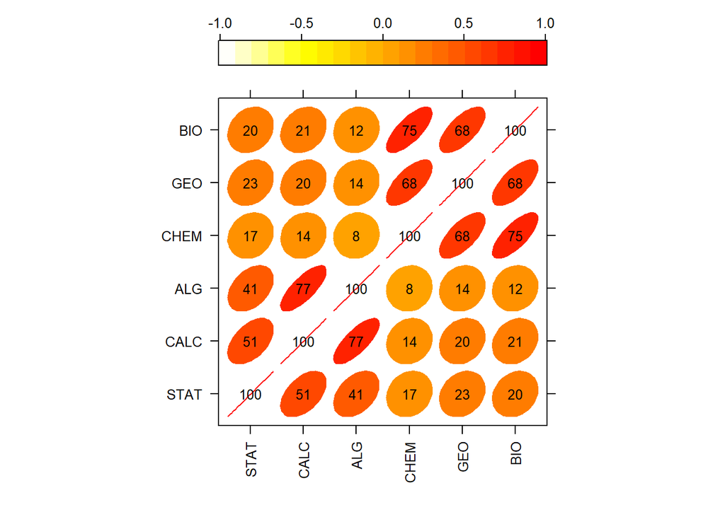

```r
cor_df <- cor(df)

# Function to generate correlation plot
panel.corrgram <- function(x, y, z, subscripts, at, level = 0.9, label = FALSE, ...) {
     require("ellipse", quietly = TRUE)
     x <- as.numeric(x)[subscripts]
     y <- as.numeric(y)[subscripts]
     z <- as.numeric(z)[subscripts]
     zcol <- level.colors(z, at = at,  ...)
     for (i in seq(along = z)) {
         ell=ellipse(z[i], level = level, npoints = 50,
                     scale = c(.2, .2), centre = c(x[i], y[i]))
         panel.polygon(ell, col = zcol[i], border = zcol[i], ...)
     }
     if (label)
         panel.text(x = x, y = y, lab = 100 * round(z, 2), cex = 0.8,
                    col = ifelse(z < 0, "white", "black"))
 }

# generate correlation plot
print(levelplot(cor_df[seq(6,1), seq(6,1)], at = do.breaks(c(-1.01, 1.01), 20),
           xlab = NULL, ylab = NULL, colorkey = list(space = "top"), col.regions=rev(heat.colors(100)),
           scales = list(x = list(rot = 90)),
           panel = panel.corrgram, label = TRUE))
```

### Scree Plot and Number of Factors

- Next, we can do PCA and examine the scree plot.
- Note that the “elbow” occurs at $m=3$.

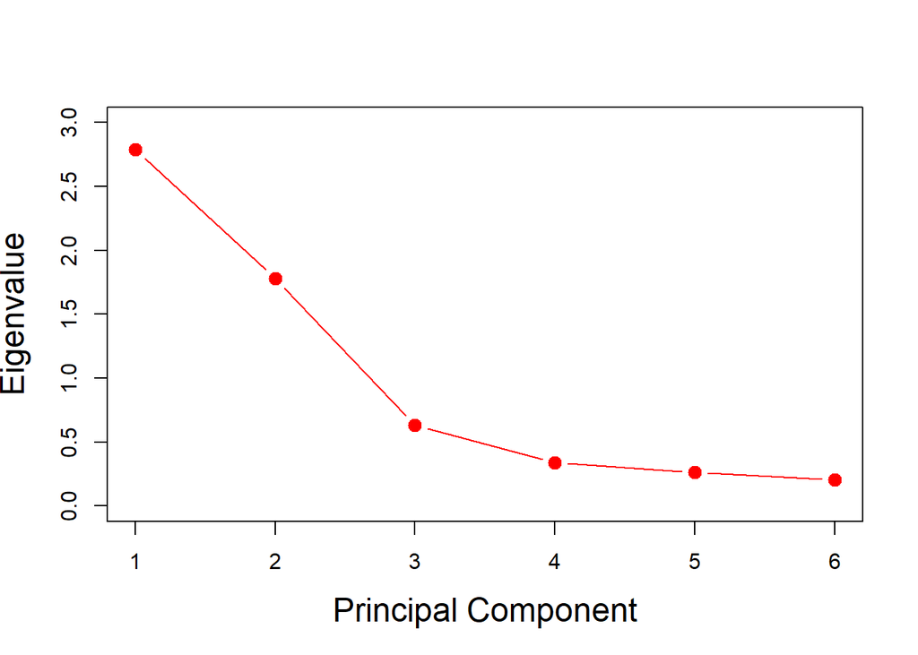

```r
# Generate scree plot
pca_result <- prcomp (df, scale =TRUE)
eigen_val <- pca_result$sdev^2
pve <- eigen_val/sum(eigen_val)

plot(eigen_val  , xlab=" Principal Component ", ylab=" Eigenvalue ",
     ylim=c(0,3), xaxt="n" ,type='b', col="red", cex=2,
pch=20, cex.lab=1.5)
axis(1, at=c(1,2,3,4,5,6),labels=c(1,2,3,4,5,6))
```

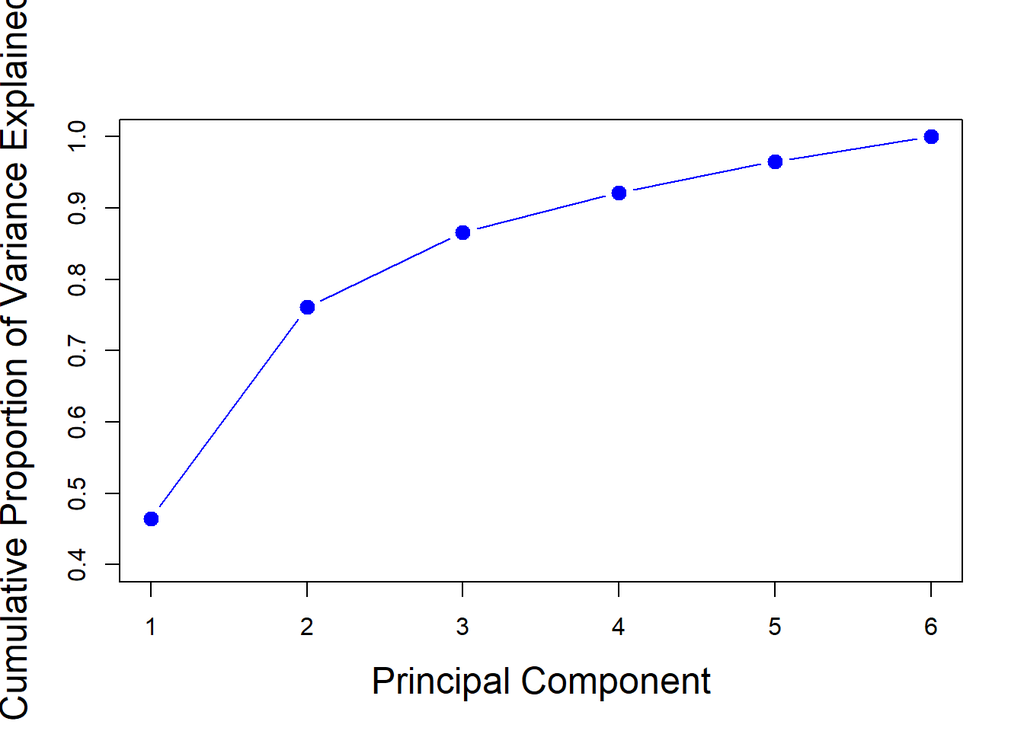

```r
# Cumulative Proportion plot
plot(cumsum(pve), xlab=" Principal Component ",
  ylab ="Cumulative Proportion of Variance Explained ",
  ylim=c(0.4,1) , xaxt="n",type='b', col="blue", cex=2, pch=20, cex.lab=1.5)
axis(1, at=c(1,2,3,4,5,6),labels=c(1,2,3,4,5,6))
```

### Factor Analysis with $m=2$

- We choose $m=2$ and estimate the factor model with MLE method.
- The estimated factor loadings are reported in the following table.
- The first factor loads heavily on Biology, Geology and Chemistry.
- The second factor loads heavily on Algebra, Calculus and Statistics.
- This gives us a good interpretation of common factors. The first factor indicates the common variation of science subjects, while the second factor indicates the common variation of math subjects.

```r
# Set the number of factors as 2
n.factors <- 2

# Fit factor model (in base R)
# The n.factors denotes how many factors used in fitting
# The scores option denotes how the factor scores are calcualted
# The rotation option denotes what rotation matrix is used
fa_fit <- factanal(df, n.factors, rotation="varimax")

# Factor loadings
loading <- fa_fit$loadings[,1:2]
t(loading)
```

```
##               BIO       GEO       CHEM        ALG       CALC      STAT
## Factor1 0.8545634 0.7793285 0.86460737 0.03133486 0.09671653 0.1699850
## Factor2 0.1325705 0.1345507 0.05545425 0.79070534 0.97107765 0.5061215
```

### Visualize Factor Loading Matrix

- We can visualize the estimated factor loadings on the two-dimensional plane spanned by the two factors.
- Each subject is plotted as a point on this plane according to its factor loading values.
- As suggested by the factor loading results, science subjects load heavily on the first factor but lightly on the second.
- In contrast, math subjects load heavily on the second factor but lightly on the first.
- We can see that the two types of subjects (science and math) are well separated in the plane spanned by two factors.
- This factor model gives us a good explanation of the dataset.
- The factor analysis suggests us to model the preference of subjects similarly within each type, but differently between these two types.

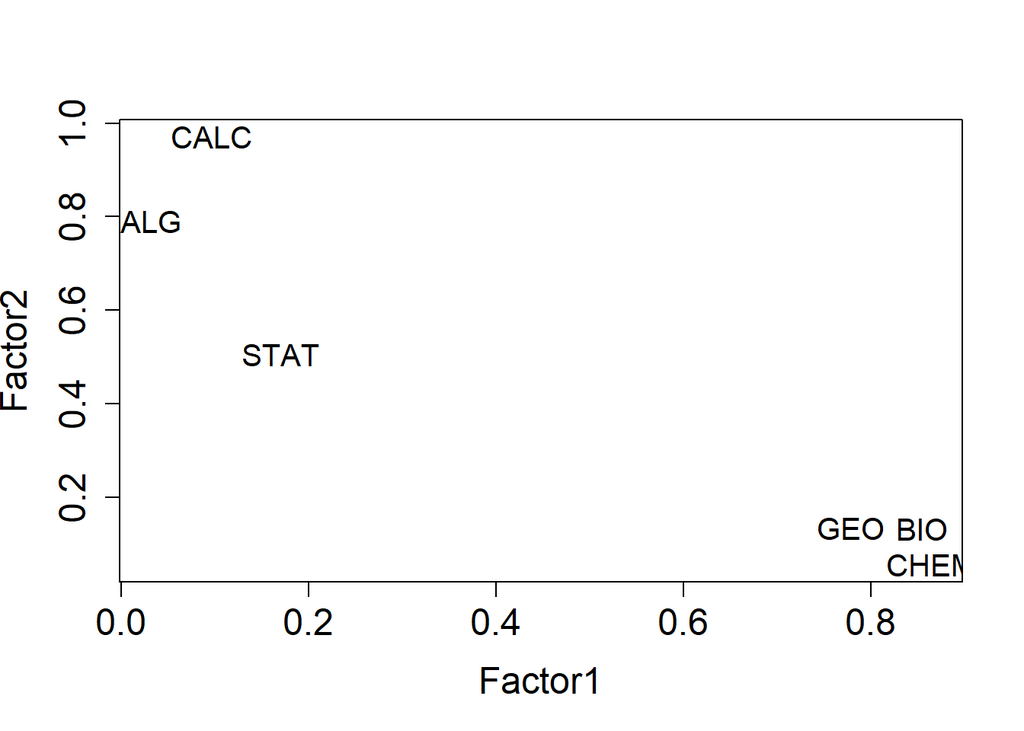

```r
# Visualize factor loadings
plot(loading,type="n",cex.axis=1.5,cex.lab=1.5) # set up plot
text(loading,labels=names(df),cex=1.25)
```